# Using RFM Models the Online Retail Dataset

# 1 Load Data

We first want to load our dataset and prepare them as before.

```r
tnx_data_tbl <- read_rds("data/retail_data_cleaned_tbl.rds")

tnx_data_tbl %>% glimpse()
```

```
## Rows: 1,044,848
## Columns: 23
## $ row_id            <chr> "ROW0000001", "ROW0000002", "ROW0000003", "ROW000000…
## $ excel_sheet       <chr> "Year 2009-2010", "Year 2009-2010", "Year 2009-2010"…
## $ invoice_id        <chr> "489434", "489434", "489434", "489434", "489434", "4…
## $ stock_code        <chr> "85048", "79323P", "79323W", "22041", "21232", "2206…
## $ description       <chr> "15CM CHRISTMAS GLASS BALL 20 LIGHTS", "PINK CHERRY …
## $ quantity          <dbl> 12, 12, 12, 48, 24, 24, 24, 10, 12, 12, 24, 12, 10, …
## $ invoice_date      <date> 2009-12-01, 2009-12-01, 2009-12-01, 2009-12-01, 200…
## $ price             <dbl> 6.95, 6.75, 6.75, 2.10, 1.25, 1.65, 1.25, 5.95, 2.55…
## $ customer_id       <chr> "13085", "13085", "13085", "13085", "13085", "13085"…
## $ country           <chr> "United Kingdom", "United Kingdom", "United Kingdom"…
## $ stock_code_upr    <chr> "85048", "79323P", "79323W", "22041", "21232", "2206…
## $ cancellation      <lgl> FALSE, FALSE, FALSE, FALSE, FALSE, FALSE, FALSE, FAL…
## $ invoice_dttm      <dttm> 2009-12-01 07:45:00, 2009-12-01 07:45:00, 2009-12-0…
## $ invoice_month     <fct> December, December, December, December, December, De…
## $ invoice_dow       <fct> Tuesday, Tuesday, Tuesday, Tuesday, Tuesday, Tuesday…
## $ invoice_dom       <chr> "01", "01", "01", "01", "01", "01", "01", "01", "01"…
## $ invoice_hour      <chr> "07", "07", "07", "07", "07", "07", "07", "07", "07"…
## $ invoice_minute    <chr> "45", "45", "45", "45", "45", "45", "45", "45", "45"…
## $ invoice_woy       <chr> "49", "49", "49", "49", "49", "49", "49", "49", "49"…
## $ invoice_ym        <chr> "200912", "200912", "200912", "200912", "200912", "2…
## $ stock_value       <dbl> 83.40, 81.00, 81.00, 100.80, 30.00, 39.60, 30.00, 59…
## $ invoice_monthprop <dbl> 0.04347826, 0.04347826, 0.04347826, 0.04347826, 0.04…
## $ exclude           <lgl> FALSE, FALSE, FALSE, FALSE, FALSE, FALSE, FALSE, FAL…
```

Having loaded the transaction data we also want to load the daily summary datasets.

```r
daily_spend_invoice_tbl <- read_rds("data/daily_spend_invoice_tbl.rds")
daily_spend_invoice_tbl %>% glimpse()
```

```
## Rows: 36,594
## Columns: 4
## $ invoice_date  <date> 2009-12-01, 2009-12-01, 2009-12-01, 2009-12-01, 2009-12…
## $ customer_id   <chr> "12490", "12533", "12682", "12758", "12836", "12913", "1…
## $ invoice_id    <chr> "489557", "489526", "489439", "489599", "489593", "48954…
## $ invoice_spend <dbl> 531.94, 821.92, 372.30, 2454.68, 423.87, 537.96, 261.00,…
```

```r
daily_spend_tbl <- read_rds("data/daily_spend_tbl.rds")
daily_spend_tbl %>% glimpse()
```

```
## Rows: 32,878
## Columns: 4
## $ invoice_date <date> 2009-12-01, 2009-12-01, 2009-12-01, 2009-12-01, 2009-12-…
## $ customer_id  <chr> "12490", "12533", "12682", "12758", "12836", "12913", "12…
## $ total_spend  <dbl> 531.94, 821.92, 372.30, 2454.68, 423.87, 537.96, 261.00, …
## $ tnx_count    <int> 1, 1, 1, 1, 1, 1, 1, 1, 1, 2, 1, 1, 1, 1, 1, 2, 1, 1, 1, …
```

Finally, we want to set a date to make the end of the “fitting” data, which will be used in the various estimation routines to fit parameters of our models.

```r
training_data_date <- as.Date("2011-03-31")
```

# 2 Basic RFM Analysis

We have some basic transaction data so we now add this to routines provided by the `rfm` package.

```r
customer_rfmdata <- daily_spend_invoice_tbl %>%
  filter(invoice_date <= training_data_date) %>%
  rfm_table_order(
    customer_id   = customer_id,
    order_date    = invoice_date,
    revenue       = invoice_spend,
    analysis_date = training_data_date
    )

customer_rfmdata %>% print()
```

```
## # A tibble: 4,691 × 9
##    customer_id date_most_recent recency_days transaction_count amount
##    <chr>       <date>                  <dbl>             <dbl>  <dbl>
##  1 12346       2011-01-18                 72                 3 77353.
##  2 12347       2011-01-26                 64                 3  1799.
##  3 12348       2011-01-25                 65                 3  1061.
##  4 12349       2010-10-28                154                 2  2221.
##  5 12350       2011-02-02                 57                 1   294.
##  6 12351       2010-11-29                122                 1   301.
##  7 12352       2011-03-22                  9                 6   985.
##  8 12353       2010-10-27                155                 1   318.
##  9 12355       2010-05-21                314                 1   488.
## 10 12356       2011-01-18                 72                 4  5074.
## # … with 4,681 more rows, and 4 more variables: recency_score <int>,
## #   frequency_score <int>, monetary_score <int>, rfm_score <dbl>
```

## 2.1 RFM Visualisations

We now want to look at a few provided visualisations of this data.

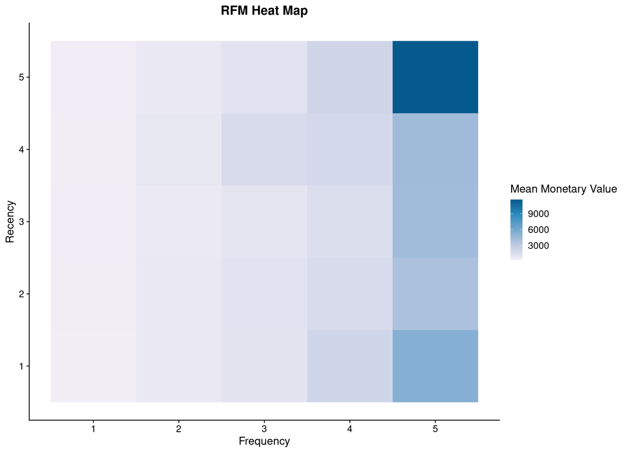

```r
customer_rfmdata %>% rfm_heatmap()
```

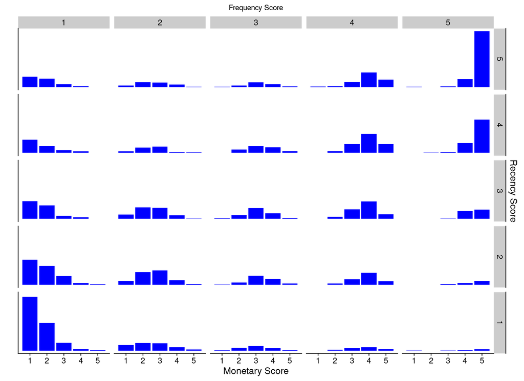

```r
customer_rfmdata %>% rfm_bar_chart()
```

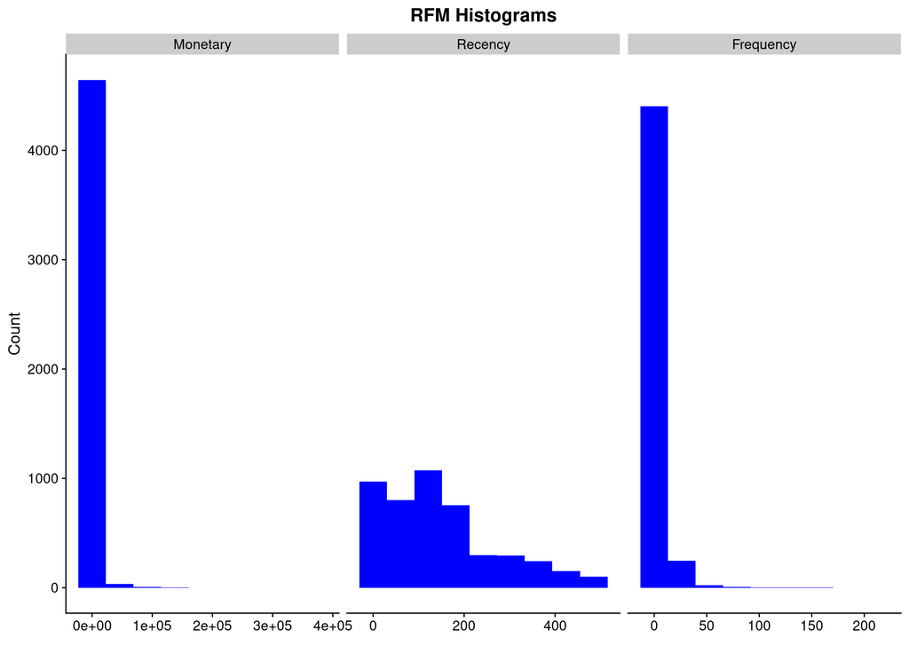

```r
customer_rfmdata %>% rfm_histograms()
```

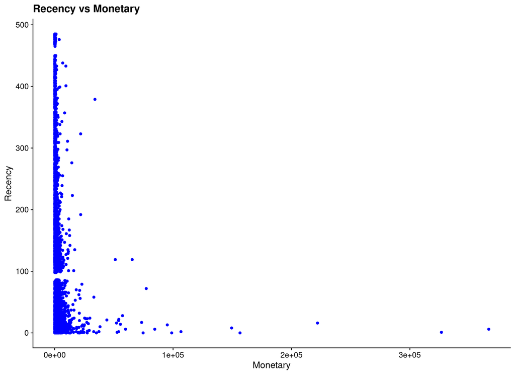

```r
customer_rfmdata %>% rfm_rm_plot()
```

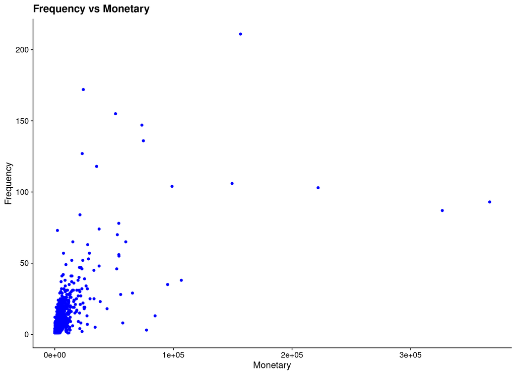

```r
customer_rfmdata %>% rfm_fm_plot()
```

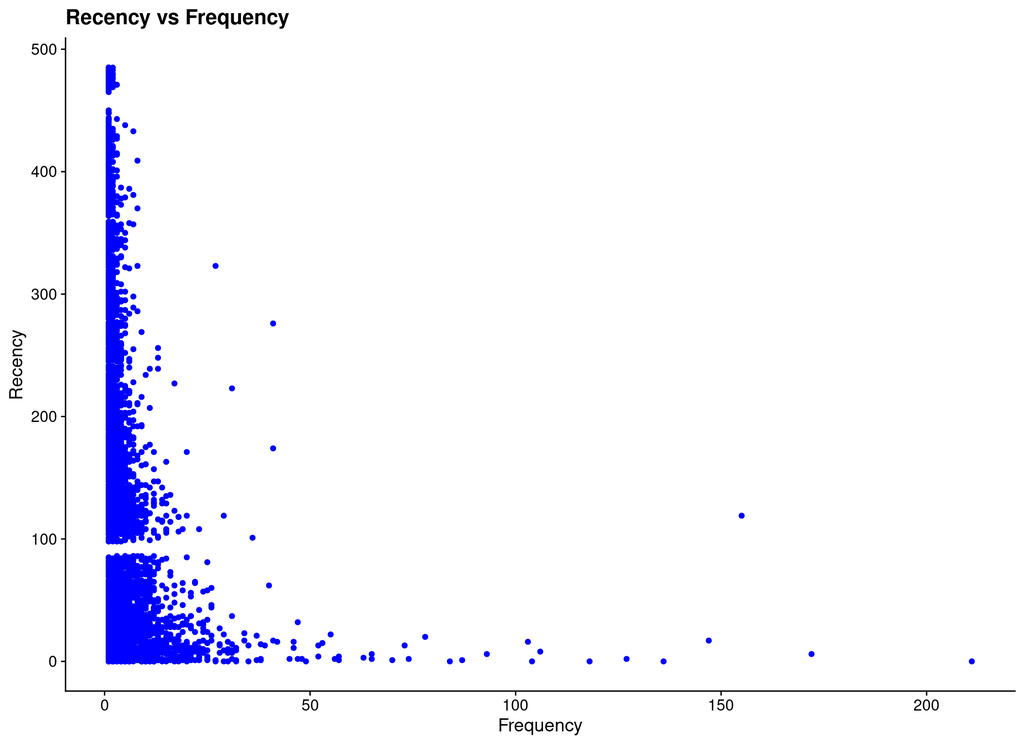

```r
customer_rfmdata %>% rfm_rf_plot()
```

# 3 Customer Segments

We can use the RFM measures to segment our customer base, and to do so we need to first define each of the segments.

```r
segment_names <- c(
  "Champions", "Loyal Customers", "Potential Loyalist", "New Customers",
  "Promising", "Need Attention", "About To Sleep", "At Risk",
  "Can't Lose Them", "Lost"
  )

recency_lower   <- c(4, 2, 3, 4, 3, 2, 2, 1, 1, 1)
recency_upper   <- c(5, 5, 5, 5, 4, 3, 3, 2, 1, 2)
frequency_lower <- c(4, 3, 1, 1, 1, 2, 1, 2, 4, 1)
frequency_upper <- c(5, 5, 3, 1, 1, 3, 2, 5, 5, 2)
monetary_lower  <- c(4, 3, 1, 1, 1, 2, 1, 2, 4, 1)
monetary_upper  <- c(5, 5, 3, 1, 1, 3, 2, 5, 5, 2)

segment_defs_tbl <- tibble(
  segment_names,
  recency_lower,
  recency_upper,
  frequency_lower,
  frequency_upper,
  monetary_lower,
  monetary_upper
  )

segment_defs_tbl %>% glimpse()
```

```
## Rows: 10
## Columns: 7
## $ segment_names   <chr> "Champions", "Loyal Customers", "Potential Loyalist", …
## $ recency_lower   <dbl> 4, 2, 3, 4, 3, 2, 2, 1, 1, 1
## $ recency_upper   <dbl> 5, 5, 5, 5, 4, 3, 3, 2, 1, 2
## $ frequency_lower <dbl> 4, 3, 1, 1, 1, 2, 1, 2, 4, 1
## $ frequency_upper <dbl> 5, 5, 3, 1, 1, 3, 2, 5, 5, 2
## $ monetary_lower  <dbl> 4, 3, 1, 1, 1, 2, 1, 2, 4, 1
## $ monetary_upper  <dbl> 5, 5, 3, 1, 1, 3, 2, 5, 5, 2
```

We first visually inspect these segment definitions and the bands.

```r
segments_show_tbl <- segment_defs_tbl %>%
  mutate(
    recency   = glue("{recency_lower}-{recency_upper}")     %>% as.character(),
    frequency = glue("{frequency_lower}-{frequency_upper}") %>% as.character(),
    monetary  = glue("{monetary_lower}-{monetary_upper}")   %>% as.character()
    ) %>%
  select(
    segment_names, recency, frequency, monetary
    )

segments_show_tbl %>%
  datatable(
    colnames = c("Segment", "R", "F", "M"),
    options = list(
      columnDefs = list(list(className = 'dt-left', targets = 0:4))
      )
    )
```

|  | Segment | R | F | M |
| --- | --- | --- | --- | --- |
| 1 | Champions | 4-5 | 4-5 | 4-5 |
| 2 | Loyal Customers | 2-5 | 3-5 | 3-5 |
| 3 | Potential Loyalist | 3-5 | 1-3 | 1-3 |
| 4 | New Customers | 4-5 | 1-1 | 1-1 |
| 5 | Promising | 3-4 | 1-1 | 1-1 |
| 6 | Need Attention | 2-3 | 2-3 | 2-3 |
| 7 | About To Sleep | 2-3 | 1-2 | 1-2 |
| 8 | At Risk | 1-2 | 2-5 | 2-5 |
| 9 | Can't Lose Them | 1-1 | 4-5 | 4-5 |
| 10 | Lost | 1-2 | 1-2 | 1-2 |

We now want to check all the different possibilities for customers to check if it is possible for some combinations to fit in multiple categories, as this can help with segment definition.

```r
select_customer_segment <- function(rc, fr, mn, data_tbl) {
  selection_tbl <- data_tbl %>%
    filter(
      recency_lower   <= rc, rc <= recency_upper,
      frequency_lower <= fr, fr <= frequency_upper,
      monetary_lower  <= mn, mn <= monetary_upper,
      )

  return(selection_tbl)
}

test_customer_tbl <- expand_grid(
    recency   = 1:5,
    frequency = 1:5,
    monetary  = 1:5
    ) %>%
  mutate(
    segment_id = 1:n(),

    .before = 1
    ) %>%
  mutate(
    select_data = pmap(
      list(rc = recency, fr = frequency, mn = monetary),
      select_customer_segment,
      data_tbl = segment_defs_tbl
      )
    )

test_customer_tbl %>% glimpse()
```

```
## Rows: 125
## Columns: 5
## $ segment_id  <int> 1, 2, 3, 4, 5, 6, 7, 8, 9, 10, 11, 12, 13, 14, 15, 16, 17,…
## $ recency     <int> 1, 1, 1, 1, 1, 1, 1, 1, 1, 1, 1, 1, 1, 1, 1, 1, 1, 1, 1, 1…
## $ frequency   <int> 1, 1, 1, 1, 1, 2, 2, 2, 2, 2, 3, 3, 3, 3, 3, 4, 4, 4, 4, 4…
## $ monetary    <int> 1, 2, 3, 4, 5, 1, 2, 3, 4, 5, 1, 2, 3, 4, 5, 1, 2, 3, 4, 5…
## $ select_data <list> [<tbl_df[1 x 7]>], [<tbl_df[1 x 7]>], [<tbl_df[0 x 7]>], …
```

Now we check these definitions against our customers and in particular we need to focus on customers assigned to none of the segments, and customers assigned to multiple segments.

```r
missing_customer_segments_tbl <- test_customer_tbl %>%
  filter(map_int(select_data, nrow) == 0) %>%
  select(-select_data)

missing_customer_segments_tbl %>% datatable()
```

|  | segment_id | recency | frequency | monetary |
| --- | --- | --- | --- | --- |
| 1 | 3 | 1 | 1 | 3 |
| 2 | 4 | 1 | 1 | 4 |
| 3 | 5 | 1 | 1 | 5 |
| 4 | 11 | 1 | 3 | 1 |
| 5 | 16 | 1 | 4 | 1 |
| 6 | 21 | 1 | 5 | 1 |
| 7 | 28 | 2 | 1 | 3 |
| 8 | 29 | 2 | 1 | 4 |
| 9 | 30 | 2 | 1 | 5 |
| 10 | 36 | 2 | 3 | 1 |

[output cut: 26 more lines]

## 3.1 Analysing the Customer Segments

Now that we have checked our definitions, we categorise each of the customers into one of these segments.

```r
customer_segments_tbl <- customer_rfmdata %>%
  rfm_segment(
    segment_names   = segment_names,
    recency_lower   = recency_lower,
    recency_upper   = recency_upper,
    frequency_lower = frequency_lower,
    frequency_upper = frequency_upper,
    monetary_lower  = monetary_lower,
    monetary_upper  = monetary_upper
    )

customer_segments_tbl %>% glimpse()
```

```
## Rows: 4,691
## Columns: 9
## $ customer_id       <chr> "12346", "12347", "12348", "12349", "12350", "12351"…
## $ segment           <chr> "Loyal Customers", "Loyal Customers", "Loyal Custome…
## $ rfm_score         <dbl> 435, 434, 434, 224, 412, 312, 543, 212, 112, 445, 31…
## $ transaction_count <dbl> 3, 3, 3, 2, 1, 1, 6, 1, 1, 4, 1, 3, 8, 3, 4, 1, 1, 1…
## $ recency_days      <dbl> 72, 64, 65, 154, 57, 122, 9, 155, 314, 72, 135, 122,…
## $ amount            <dbl> 77352.96, 1798.71, 1061.40, 2221.14, 294.40, 300.93,…
## $ recency_score     <int> 4, 4, 4, 2, 4, 3, 5, 2, 1, 4, 3, 3, 4, 3, 4, 4, 4, 1…
## $ frequency_score   <int> 3, 3, 3, 2, 1, 1, 4, 1, 1, 4, 1, 3, 5, 3, 4, 1, 1, 1…
## $ monetary_score    <int> 5, 4, 4, 4, 2, 2, 3, 2, 2, 5, 5, 5, 5, 4, 2, 2, 2, 2…
```

Having assigned the customers to each segment we now can now use this data to run some summary information.

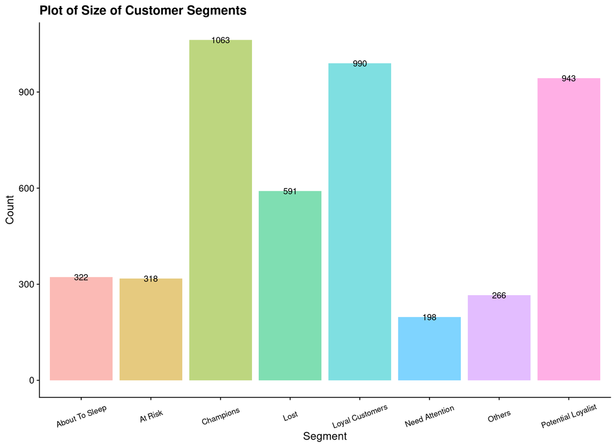

```r
plot_tbl <- customer_segments_tbl %>% count(segment)

ggplot(plot_tbl) +
  geom_col(aes(x = segment, y = n, fill = segment), alpha = 0.50) +
  geom_text(aes(x = segment, y = n, label = n)) +
  labs(
    x = "Segment",
    y = "Count",
    title = "Plot of Size of Customer Segments"
    ) +
  theme(
    legend.position = "none",
    axis.text.x = element_text(size = 10, angle = 20, vjust = 0.5)
    )
```

Finally, we produce boxplots of the customer segments by the various metrics we have calculated.

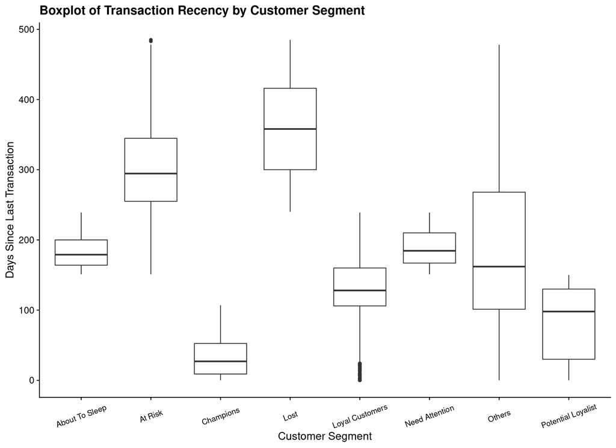

```r
ggplot(customer_segments_tbl) +
  geom_boxplot(aes(x = segment, y = recency_days)) +
  labs(
    x = "Customer Segment",
    y = "Days Since Last Transaction",
    title = "Boxplot of Transaction Recency by Customer Segment"
    ) +
  theme(
    axis.text.x = element_text(size = 10, angle = 20, vjust = 0.5)
    )
```

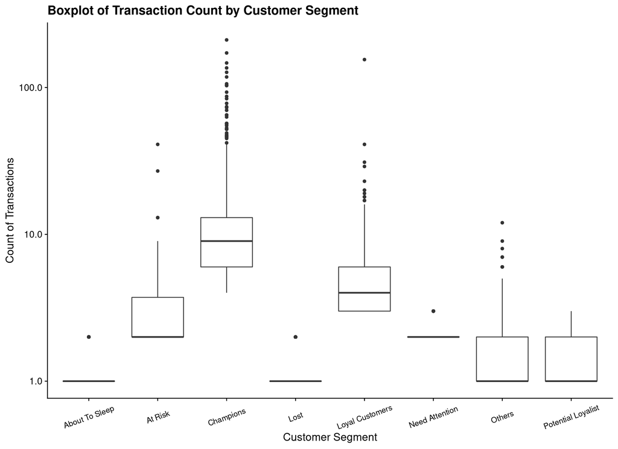

```r
ggplot(customer_segments_tbl) +
  geom_boxplot(aes(x = segment, y = transaction_count)) +
  scale_y_log10(labels = label_comma()) +
  expand_limits(y = 0) +
  labs(
    x = "Customer Segment",
    y = "Count of Transactions",
    title = "Boxplot of Transaction Count by Customer Segment"
    ) +
  theme(
    axis.text.x = element_text(size = 10, angle = 20, vjust = 0.5)
    )
```

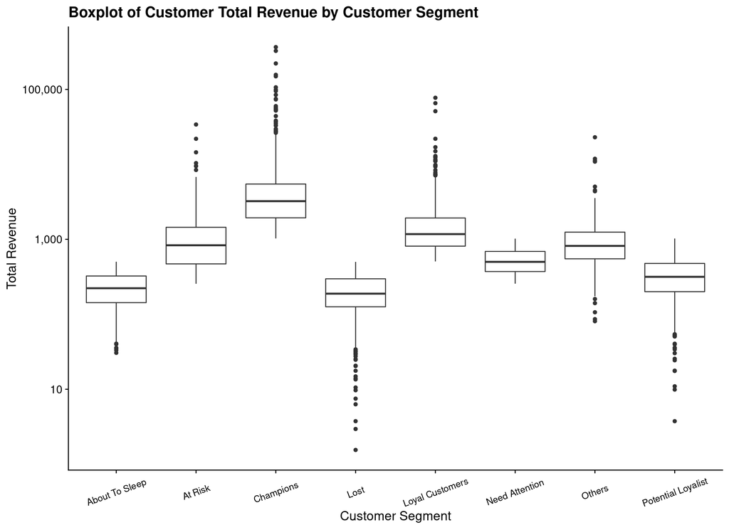

```r
ggplot(customer_segments_tbl) +
  geom_boxplot(aes(x = segment, y = amount)) +
  scale_y_log10(labels = label_comma()) +
  expand_limits(y = 0) +
  labs(
    x = "Customer Segment",
    y = "Total Revenue",
    title = "Boxplot of Customer Total Revenue by Customer Segment"
    ) +
  theme(
    axis.text.x = element_text(size = 10, angle = 20, vjust = 0.5)
    )
```

## 3.2 Out-of-Sample Segment Validation

We can check the validity or usefulness of these segments by using the segment classification on the data from after our cutoff date. If our segments are useful we should see some discrimination between them in the data.

```r
customer_segment_classification_tbl <- customer_segments_tbl %>%
  select(customer_id, segment)

post_cutoff_data_tbl <- daily_spend_invoice_tbl %>%
  filter(invoice_date > training_data_date)

customer_summary_tbl <- post_cutoff_data_tbl %>%
  group_by(customer_id) %>%
  summarise(
    most_recent_purchase = max(invoice_date),
    transaction_count    = n(),
    total_purchase       = sum(invoice_spend)
    )

customer_summary_tbl %>% glimpse()
```

```
## Rows: 3,843
## Columns: 4
## $ customer_id          <chr> "12347", "12348", "12349", "12352", "12353", "123…
## $ most_recent_purchase <date> 2011-12-07, 2011-09-25, 2011-11-21, 2011-11-03, …
## $ transaction_count    <int> 5, 2, 1, 3, 1, 1, 1, 2, 1, 2, 2, 3, 9, 2, 4, 1, 1…
## $ total_purchase       <dbl> 3122.82, 597.00, 1457.55, 744.23, 89.00, 1079.40,…
```

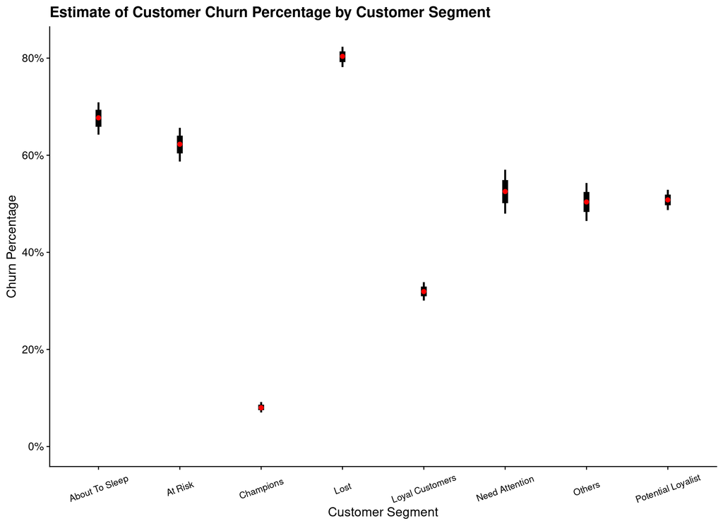

```r
segment_check_tbl <- customer_segment_classification_tbl %>%
  left_join(customer_summary_tbl, by = "customer_id") %>%
  group_by(segment) %>%
  mutate(
    segment_count = n(),

    .after = "segment"
    ) %>%
  ungroup()

plot_tbl <- segment_check_tbl %>%
  group_by(segment) %>%
  summarise(
    count_total = n(),
    count_dead  = sum(are_na(transaction_count))
    ) %>%
  mutate(
    count_alive = count_total - count_dead,

    dropped_prop = count_dead / count_total,
    dropped_p10  = qbeta(0.10, count_dead + 1, count_alive + 1),
    dropped_p25  = qbeta(0.25, count_dead + 1, count_alive + 1),
    dropped_p50  = qbeta(0.50, count_dead + 1, count_alive + 1),
    dropped_p75  = qbeta(0.75, count_dead + 1, count_alive + 1),
    dropped_p90  = qbeta(0.90, count_dead + 1, count_alive + 1)
    )

ggplot(plot_tbl) +
  geom_errorbar(aes(x = segment, ymin = dropped_p10, ymax = dropped_p90),
                width = 0, size = 1) +
  geom_errorbar(aes(x = segment, ymin = dropped_p25, ymax = dropped_p75),
                width = 0, size = 3) +
  geom_point(aes(x = segment, y = dropped_prop),
             size = 2, colour = "red") +
  expand_limits(y = 0) +
  scale_y_continuous(labels = label_percent()) +
  labs(
    x = "Customer Segment",
    y = "Churn Percentage",
    title = "Estimate of Customer Churn Percentage by Customer Segment"
    ) +
  theme(
    axis.text.x = element_text(size = 10, angle = 20, vjust = 0.5)
    )
```

For the purposes of checking both the frequency and monetary values, we filter out those customers with no transactions after the cutoff date i.e. we only look at ‘alive’ customers.

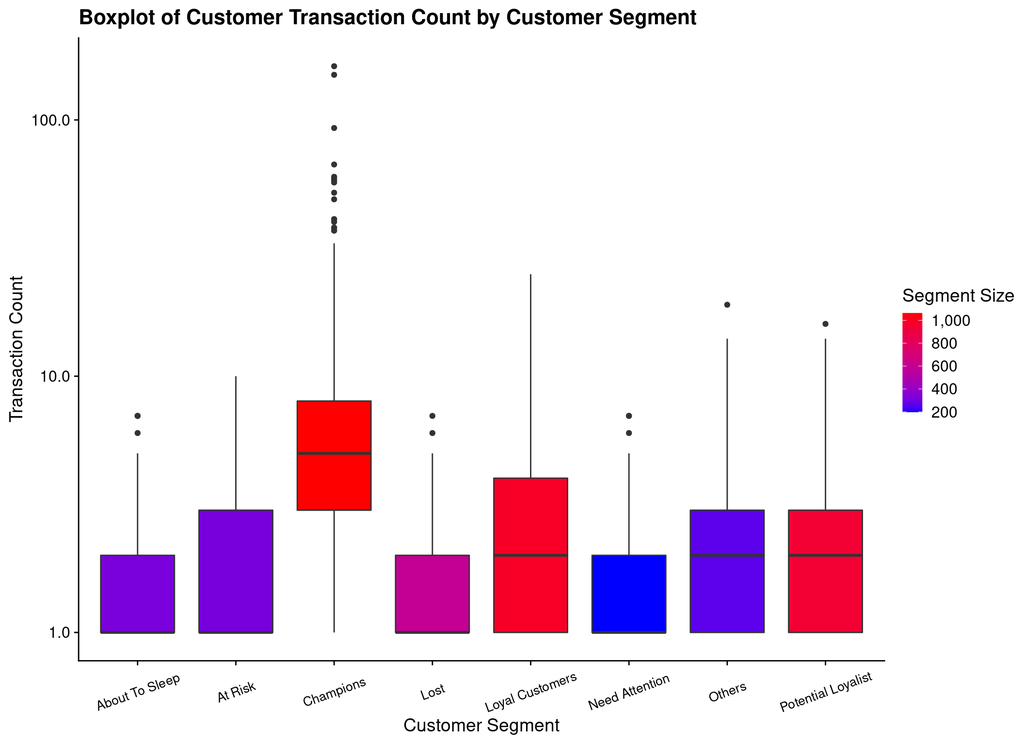

```r
plot_tbl <- segment_check_tbl %>%
  drop_na(most_recent_purchase)

ggplot(plot_tbl) +
  geom_boxplot(aes(x = segment, y = transaction_count, fill = segment_count)) +
  scale_y_log10(labels = label_comma()) +
  scale_fill_gradient(low = "blue", high = "red", labels = label_comma()) +
  expand_limits(y = 0) +
  labs(
    x = "Customer Segment",
    y = "Transaction Count",
    fill = "Segment Size",
    title = "Boxplot of Customer Transaction Count by Customer Segment"
    ) +
  theme(
    axis.text.x = element_text(size = 10, angle = 20, vjust = 0.5)
    )
```

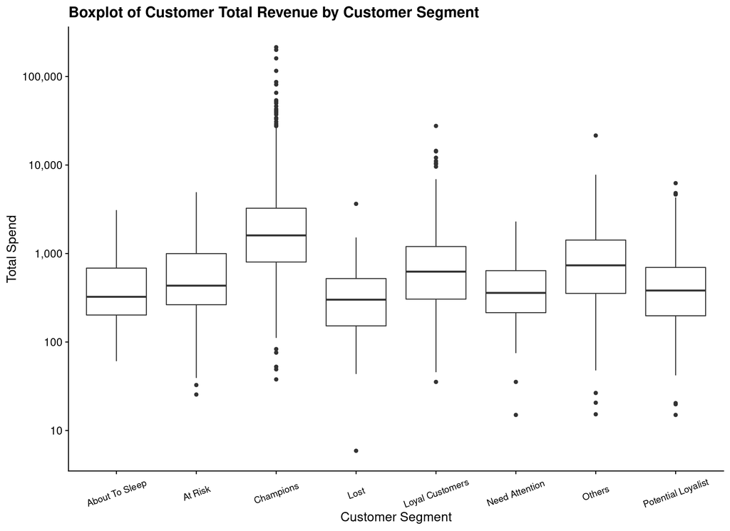

```r
ggplot(plot_tbl) +
  geom_boxplot(aes(x = segment, y = total_purchase)) +
  scale_y_log10(labels = label_comma()) +
  scale_fill_gradient(low = "blue", high = "red", labels = label_comma()) +
  expand_limits(y = 0) +
  labs(
    x = "Customer Segment",
    y = "Total Spend",
    fill = "Segment Size",
    title = "Boxplot of Customer Total Revenue by Customer Segment"
    ) +
  theme(
    axis.text.x = element_text(size = 10, angle = 20, vjust = 0.5)
    )
```